title: “Exercise5” author: “Ashish Das” date: “9/7/2021” output: html_document —

# 19BCE1160

```r
library(dplyr)
```

```r
library(help="graphics")
library(lattice)
```

### Use the newsurvey data obtained by cleaning ‘na’ values in survey data of MASS package to do the following:

```r
library(MASS)
data("survey")
str(survey)
```

```
## 'data.frame':    237 obs. of  12 variables:
##  $ Sex   : Factor w/ 2 levels "Female","Male": 1 2 2 2 2 1 2 1 2 2 ...
##  $ Wr.Hnd: num  18.5 19.5 18 18.8 20 18 17.7 17 20 18.5 ...
##  $ NW.Hnd: num  18 20.5 13.3 18.9 20 17.7 17.7 17.3 19.5 18.5 ...
##  $ W.Hnd : Factor w/ 2 levels "Left","Right": 2 1 2 2 2 2 2 2 2 2 ...
##  $ Fold  : Factor w/ 3 levels "L on R","Neither",..: 3 3 1 3 2 1 1 3 3 3 ...
##  $ Pulse : int  92 104 87 NA 35 64 83 74 72 90 ...
##  $ Clap  : Factor w/ 3 levels "Left","Neither",..: 1 1 2 2 3 3 3 3 3 3 ...
##  $ Exer  : Factor w/ 3 levels "Freq","None",..: 3 2 2 2 3 3 1 1 3 3 ...
##  $ Smoke : Factor w/ 4 levels "Heavy","Never",..: 2 4 3 2 2 2 2 2 2 2 ...
##  $ Height: num  173 178 NA 160 165 ...
##  $ M.I   : Factor w/ 2 levels "Imperial","Metric": 2 1 NA 2 2 1 1 2 2 2 ...
##  $ Age   : num  18.2 17.6 16.9 20.3 23.7 ...
```

```r
library(dplyr)
```

### Cleaning up the dataset

```r
newsurvey <- na.omit(survey)
```

### Checking if the `newsurvey` has any NA values left

```r
sum(is.na(newsurvey))
```

```
## [1] 0
```

### 1. Plot a bar graph for the number of male and female participants in the survey. Provide the title as “Male and Female participants”, y-axis label as “frequency” and specify the colours for the bars.

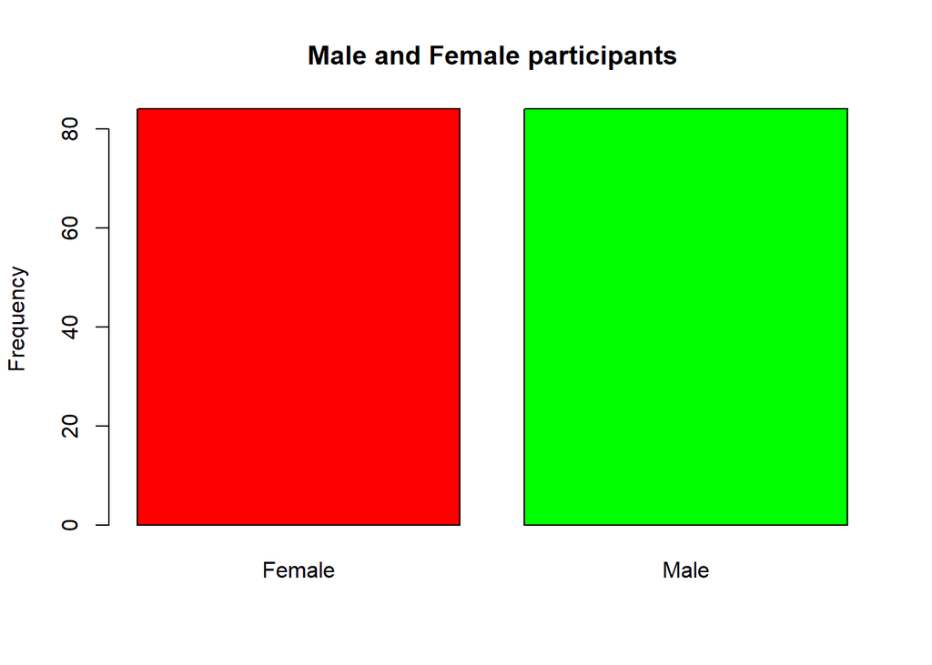

```r
barplot(table(newsurvey$Sex),col=c("red","green"), main = "Male and Female participants", ylab = "Frequency")
```

### 2. Plot a bar graph for the number of left handers and right handers in the survey. Provide the title as “Left Handers and Right Handers”, y-axis label as “count” and specify the colours for the bars.

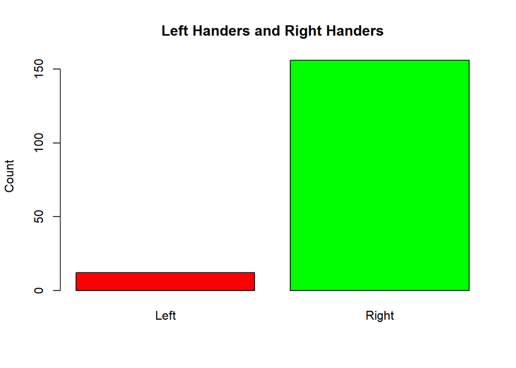

```r
barplot(table(newsurvey$W.Hnd),col=c("red","green"), main = "Left Handers and Right Handers", ylab = "Count")
```

### 3. Plot the distribution between male left handers and female left handers using bar chart. Provide the title as “Female Left Handers and Male Left Handers” , y-axis label as “count” and specify the colours for the bars.

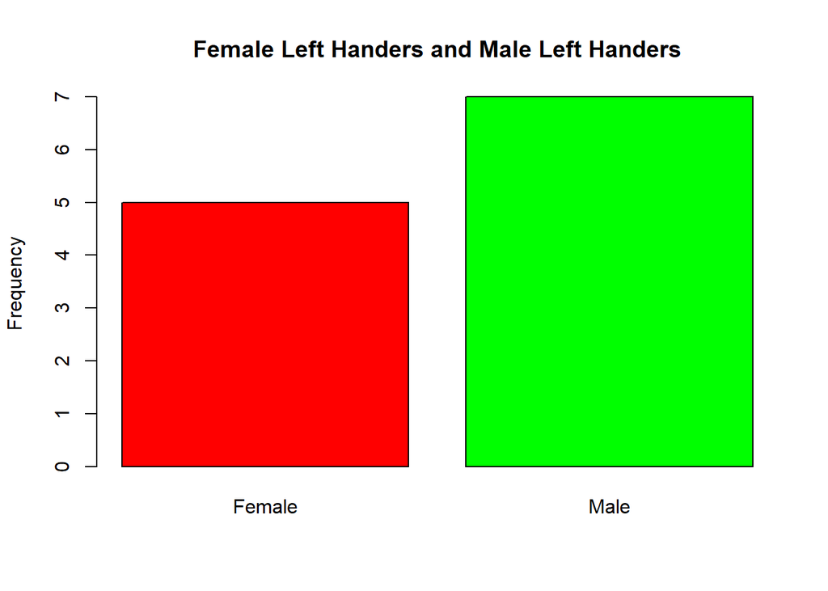

```r
left_hnd <- newsurvey %>%
    filter(W.Hnd=="Left")
barplot(table(left_hnd$Sex),col=c("red","green"), main = "Female Left Handers and Male Left Handers", ylab = "Frequency")
```

### 4. Draw the distribution of smoking habits of male left handers using pie chart.

```r
male_lefty <- newsurvey%>%
  filter(Sex=="Male", W.Hnd=="Left")
unique(male_lefty$Smoke)
```

```
## [1] Regul Never Heavy Occas
## Levels: Heavy Never Occas Regul
```

```r
table(male_lefty$Smoke)
```

```
##
## Heavy Never Occas Regul
##     1     4     1     1
```

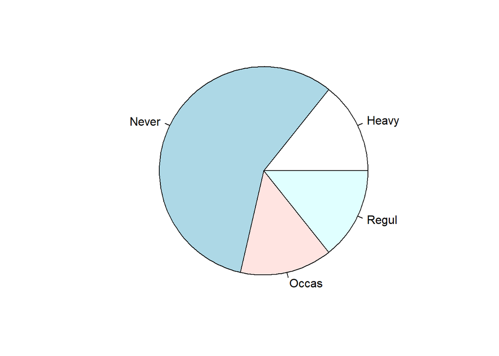

```r
pie(table(male_lefty$Smoke),radius=1)
```

### 5. Draw the histogram of age distribution with the title as ‘Age distribution’ and xlabel as ‘Age range’ and ylabel as ‘frequency’.

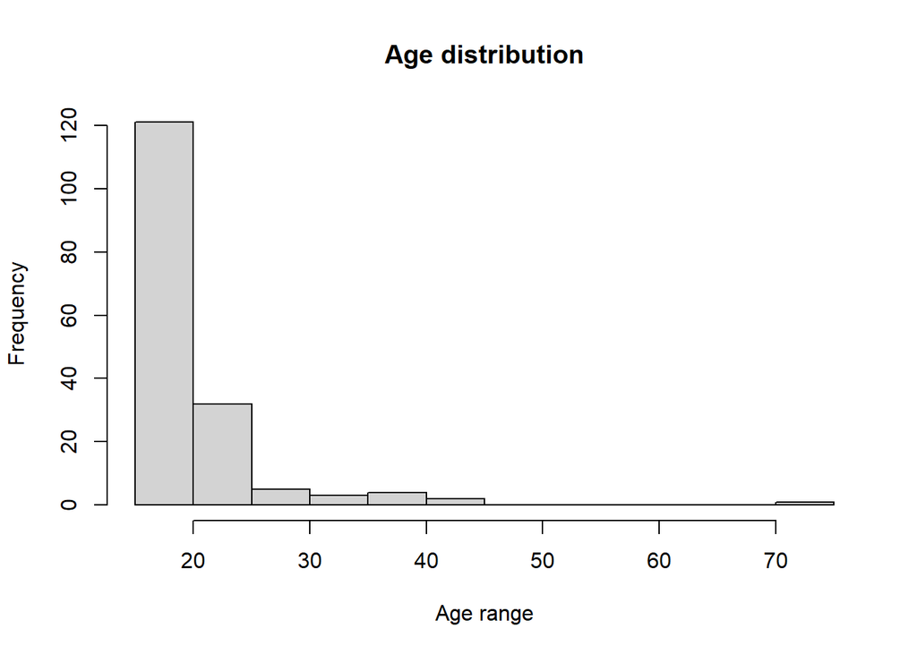

```r
hist(newsurvey$Age, main="Age distribution", ylab = "Frequency", xlab = "Age range")
```

### 6. Reveal the relationship between the age and writing hand span using scatter plot.

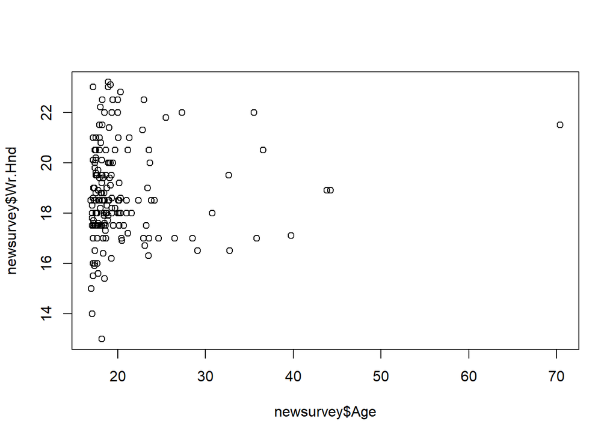

```r
plot(newsurvey$Age, newsurvey$Wr.Hnd)
```

### 7. Draw the boxplot for pulse rate to analyse the five summary statistics. Provide appropriate title and label.

```r
summary(newsurvey$Pulse)
```

```
##    Min. 1st Qu.  Median    Mean 3rd Qu.    Max.
##   35.00   66.75   72.00   74.02   80.00  104.00
```

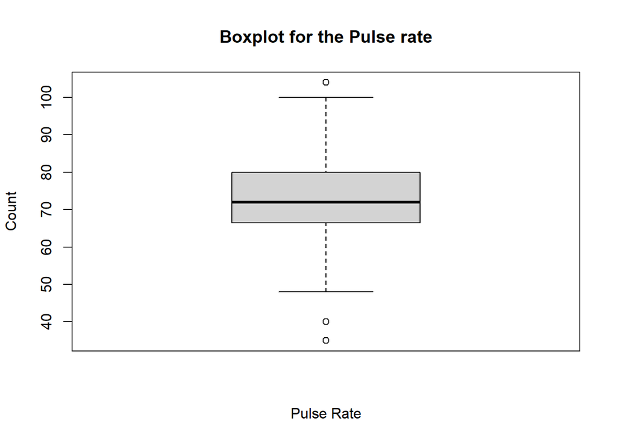

```r
boxplot(newsurvey$Pulse, main="Boxplot for the Pulse rate", ylab="Count", xlab="Pulse Rate")
```

### 8.Frame any 3 questions on data visualization to graphically depict the data that you have chosen for cleaning.

```r
nyc <- read.csv("nyc.csv")
str(nyc)
```

```
## 'data.frame':    48895 obs. of  16 variables:
##  $ id                            : int  2539 2595 3647 3831 5022 5099 5121 5178 5203 5238 ...
##  $ name                          : chr  "Clean & quiet apt home by the park" "Skylit Midtown Castle" "THE VILLAGE OF HARLEM....NEW YORK !" "Cozy Entire Floor of Brownstone" ...
##  $ host_id                       : int  2787 2845 4632 4869 7192 7322 7356 8967 7490 7549 ...
##  $ host_name                     : chr  "John" "Jennifer" "Elisabeth" "LisaRoxanne" ...
##  $ neighbourhood_group           : chr  "Brooklyn" "Manhattan" "Manhattan" "Brooklyn" ...
##  $ neighbourhood                 : chr  "Kensington" "Midtown" "Harlem" "Clinton Hill" ...
##  $ latitude                      : num  40.6 40.8 40.8 40.7 40.8 ...
##  $ longitude                     : num  -74 -74 -73.9 -74 -73.9 ...
##  $ room_type                     : chr  "Private room" "Entire home/apt" "Private room" "Entire home/apt" ...
##  $ price                         : int  149 225 150 89 80 200 60 79 79 150 ...
##  $ minimum_nights                : int  1 1 3 1 10 3 45 2 2 1 ...
##  $ number_of_reviews             : int  9 45 0 270 9 74 49 430 118 160 ...
##  $ last_review                   : chr  "2018-10-19" "2019-05-21" "" "2019-07-05" ...
##  $ reviews_per_month             : num  0.21 0.38 NA 4.64 0.1 0.59 0.4 3.47 0.99 1.33 ...
##  $ calculated_host_listings_count: int  6 2 1 1 1 1 1 1 1 4 ...
##  $ availability_365              : int  365 355 365 194 0 129 0 220 0 188 ...
```

```r
nyc_clean <- na.omit(nyc)
```

### 8.a. Draw a density plot for latitute for the data set

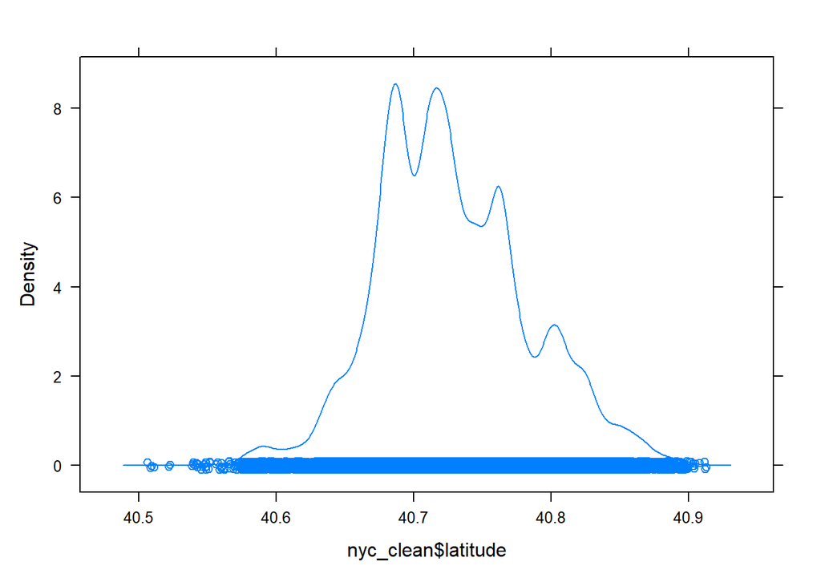

```r
densityplot(nyc_clean$latitude)
```

### 8.b. Draw a splom for the data set.

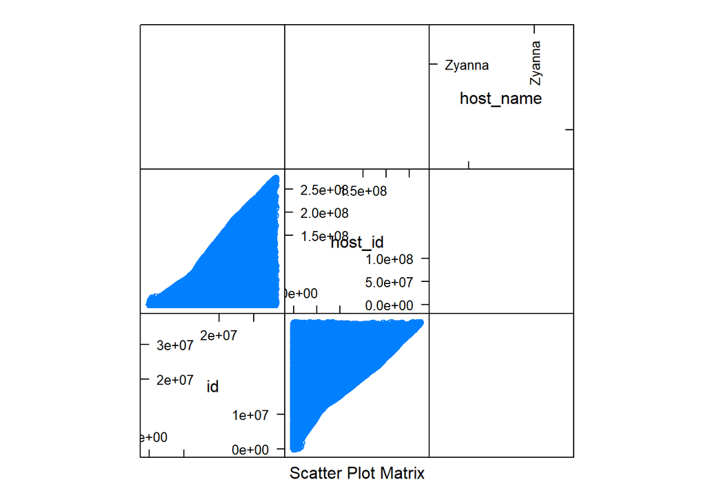

```r
splom(nyc_clean[c(1,3,4)])
```

### 8.c. Plot a bar graph for the price in the survey. Provide the title as “Price over the years”, y-axis label as “Amount in rupees”.

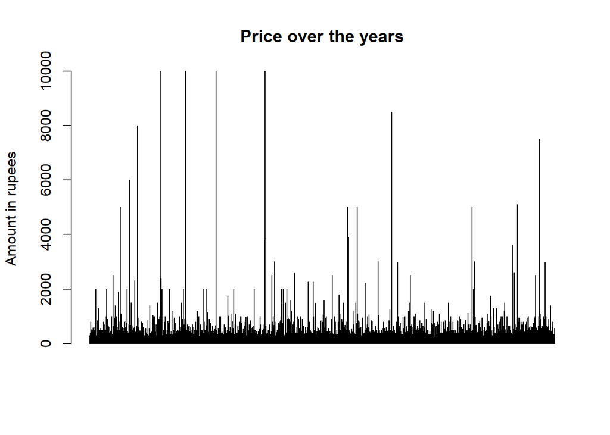

```r
barplot((nyc_clean$price),col=c("green"), main = "Price over the years", ylab = "Amount in rupees")
```